# Lab 8b Report — Visualizations (TEB2164)

Almas Nasri

2026-04-05

## Purpose

This report extends the Lab 7 analysis by adding **at least two plot types** from Lab 8a (bar chart and box plot) on the **same Titanic file** used in Lab 7 (`titanic_sort_byfare.csv`). It also uses the built-in **`chickwts`** dataset and interprets the charts as a short **“story”** for Task 2.

## Task 1 — Titanic (Lab 7 file)

```r
titanic <- read.csv(file.path(lab7, "titanic_sort_byfare.csv"), stringsAsFactors = TRUE)
tbl_ps <- table(titanic$Pclass, titanic$Survived)
tbl_ps
```

```
##
##       0   1
##   1  64 122
##   2  90  83
##   3 270  85
```

### Bar chart — class and survival

[figure not shown]

```r
barplot(
  tbl_ps,
  beside = TRUE,
  col = c("#d62728", "#2ca02c"),
  main = "Titanic: Counts by Passenger Class and Survival",
  xlab = "Passenger class",
  ylab = "Count",
  legend.text = c("Died", "Survived"),
  args.legend = list(x = "topright", bty = "n", inset = 0.02)
)
```

### Box plot — age by survival

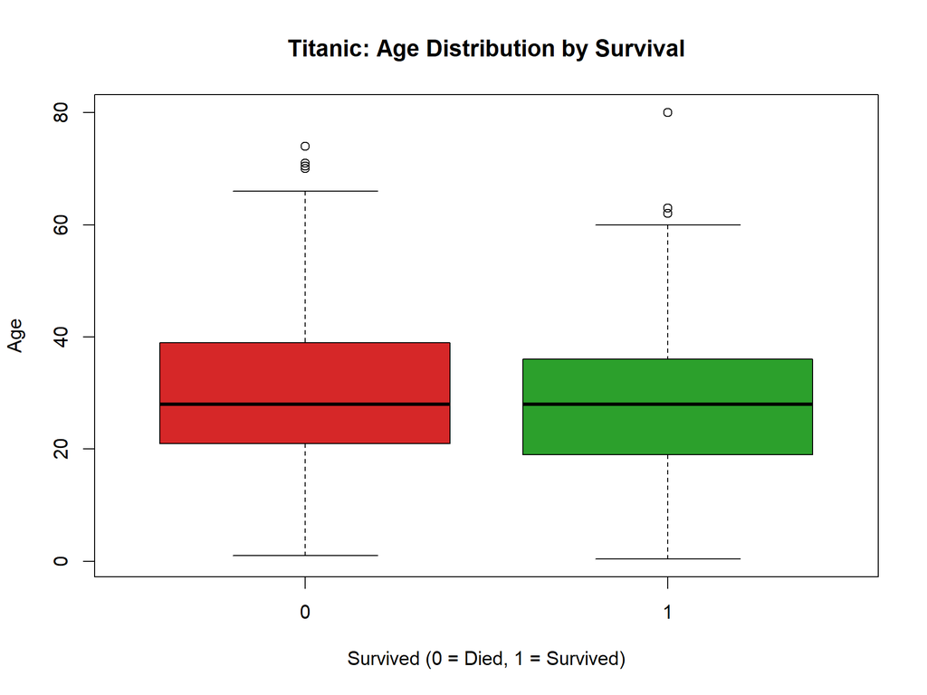

```r
boxplot(
  Age ~ Survived,
  data = titanic,
  main = "Titanic: Age Distribution by Survival",
  xlab = "Survived (0 = Died, 1 = Survived)",
  ylab = "Age",
  col = c("#d62728", "#2ca02c")
)
```

**Interpretation:** Median ages are similar for both groups; both show many younger passengers. **Outliers** at high ages appear in both groups. The plot supports discussing age alongside class and sex in your written insights (narrow age difference alone does not explain survival).

## Task 2 — `chickwts` (built-in): story for a “manager”

Imagine briefing a **farm operations manager** who must choose feed for broiler chicks. The dataset records **weight at six weeks** by **feed type** (`?chickwts` for details).

```r
data(chickwts)
str(chickwts)
```

```
## 'data.frame':    71 obs. of  2 variables:
##  $ weight: num  179 160 136 227 217 168 108 124 143 140 ...
##  $ feed  : Factor w/ 6 levels "casein","horsebean",..: 2 2 2 2 2 2 2 2 2 2 ...
```

### How many chicks per feed?

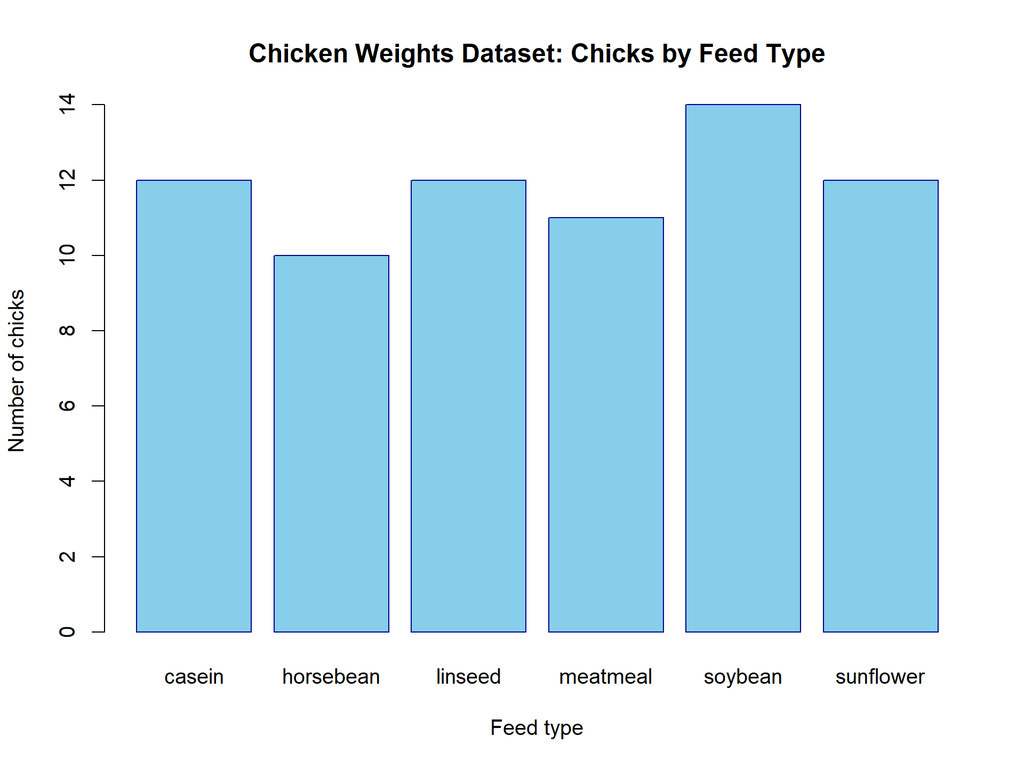

```r
feed_counts <- table(chickwts$feed)
barplot(
  feed_counts,
  main = "Chicken Weights Dataset: Chicks by Feed Type",
  xlab = "Feed type",
  ylab = "Number of chicks",
  col = "skyblue",
  border = "darkblue"
)
```

**Interpretation:** Counts per feed are **roughly balanced** (about 10–14 each), so differences in weight are **not** mainly due to unequal sample sizes.

### Weight distribution by feed

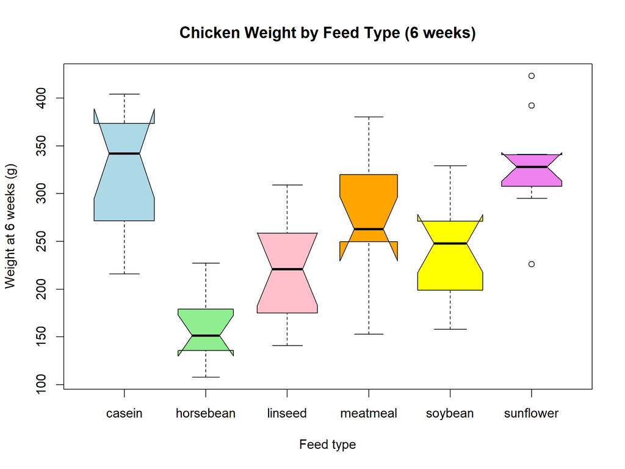

```r
boxplot(
  weight ~ feed,
  data = chickwts,
  main = "Chicken Weight by Feed Type (6 weeks)",
  xlab = "Feed type",
  ylab = "Weight at 6 weeks (g)",
  col = c("lightblue", "lightgreen", "pink", "orange", "yellow", "violet"),
  varwidth = TRUE,
  notch = TRUE
)
```

**Story (takeaway):** **Sunflower** and **casein** feeds show the **highest** typical weights; **horsebean** is clearly **lowest**. Notches and non-overlapping boxes suggest **meaningful median differences** between some feeds. A manager might shortlist **sunflower** or **casein** for trials, subject to cost and availability, and avoid **horsebean** if maximum weight at six weeks is the goal.

*TEB2164 Introduction to Data Science — Lab 8b*